# pgs-diff

Version: 1.0

# Introduction

This document is to compare different Polygenic Scores (PGS). It compares two files containing multiple Polygenic Scores and produces a density map, calculates the pearson correlation coefficient and plots a histogram where the obtained correlation coefficient are plotted according to their occurrences (countings).

However, from this analysis you cannot say which PGS is more suitable for the analysis. You can only see if there are differences or not.

# Input check

Simple check in order to be sure if the two input files are correct.

Input Files:

- File A: *output/pop-filter-results/example.1000genomes.scores.filtered.txt*
- File B: *output/pop-filter-results/example.hrc.scores.filtered.txt*

## File check

Displays the first few lines of our input files.

|  | sample | PGS000003 | PGS000030 | PGS000102 | PGS000103 | PGS000109 | PGS000160 | PGS000177 | PGS000333 | PGS000363 | PGS000388 | PGS000497 | PGS000505 | PGS000574 | PGS000601 | PGS000607 | PGS000725 | PGS000776 | PGS000844 | PGS000876 | PGS000893 | PGS000911 | PGS002242 | PGS002255 | PGS002322 | PGS002392 | PGS002416 | PGS002437 | PGS002462 | … |
| --- | --- | --- | --- | --- | --- | --- | --- | --- | --- | --- | --- | --- | --- | --- | --- | --- | --- | --- | --- | --- | --- | --- | --- | --- | --- | --- | --- | --- | --- | --- |
| 1 | Sample_1 | -0.567722798092291 | 0.352875959186349 | -0.772276905878153 | -1.43728321286476 | 0.057727126069313 | 11.5813065767288 | -1.04892207387093 | -0.418463545220232 | 0.025234778788446 | -0.315219250340369 | -0.704137554868794 | 0.606936030038924 | -0.050124649579003 | 2.50640969537199 | -0.163529137708833 | 0.041787996888161 | 0 | 0.391128142689922 | 0.044682420790196 | -2.33573587244882 | -2.2738422827022 | -0.345073271432037 | -0.046392430560151 | 0.5097556122364 | -197.425820476071 | -275.48002535314 | 3.88108950436072 | -4.50356979307662 | … |
| 2 | Sample_2 | 0.263677074806765 | 0.773851000005379 | -0.621674770929585 | -1.44085549197036 | -0.577822897644047 | 7.62472403049469 | -1.14879792094416 | -0.452019096839052 | -0.010484656437476 | -0.102808143459819 | -0.383818978687486 | 0.932870525277394 | -0.054400449015594 | 0.836868070065975 | 0.024553090986428 | -0.358524031937122 | 0 | 0.409254693907315 | 0.020838019961957 | 1.91400784759026 | -2.51578801225241 | -0.257385687950179 | -0.019272740146993 | 0.169419128365666 | -198.413180738343 | -274.329371539624 | 6.15373889784587 | 2.92667383101298 | … |
| 3 | Sample_3 | -0.470573429309297 | 0.408748985355487 | -0.59335213131602 | -1.25593873690429 | 0.635560562363904 | 4.48824123851955 | -0.597889766447224 | -0.843021607784087 | 0.061155788419021 | -0.207584609840454 | -0.19197650096612 | 0.810574505620025 | -0.239103253395345 | 2.60227999300696 | -0.067058023726296 | 0.416353963315487 | 0 | 0.482891921445116 | 0.292041327345942 | 0.910815411514704 | -2.27011454924454 | -0.187095887585016 | -0.047042458105271 | 0.213935631289048 | -197.163756756012 | -275.216503919797 | 6.15381858339242 | 5.13410256437555 | … |
| 4 | Sample_4 | -0.583960184128955 | 0.003194957971573 | -0.845117597201714 | -1.49329533931594 | 1.04627288031912 | 0.610348165035248 | -1.0357872020104 | -0.71189477043935 | 0.115349837716888 | -0.168582789535949 | -1.54527173241149 | -0.654794950882206 | -0.271316732389889 | 2.10512932843994 | -0.14216239597531 | 0.048814009409398 | 0 | 0.810075620122007 | 0.9179900145391 | 1.33393295758879 | -2.35859798589345 | -0.669133748837561 | 0.009267271997779 | -0.071169035930206 | -198.45471508626 | -274.942868537275 | 3.16984654732641 | 6.29011679250107 | … |
| 5 | Sample_5 | -0.343645531916991 | 1.15098401705109 | 0.253212093970622 | 0.103002242244238 | -0.00477143405308 | 19.5571370990947 | 0.790499681666915 | -0.176546274152196 | -0.096157282873023 | 0.029124171413958 | 0.274071125815681 | 1.0086259478885 | 0.058560319415782 | 1.71142607106594 | -0.10457462924373 | -0.477034047245979 | 0 | 0.589679388398508 | 0.214324191794731 | -2.18449862728812 | -1.29803294495165 | -0.43308385828198 | -0.016589824119923 | 0.509426450747201 | -198.556474652298 | -276.263932068888 | 7.82075135235846 | 11.593104733548 | … |
| 6 | Sample_6 | -0.333834392185963 | 0.60041001776699 | -0.651990198812803 | -1.27414026247238 | -0.117041576402909 | 13.129553979612 | -0.268395069879261 | -0.472000533366673 | 0.055527026325588 | -0.27326726354143 | -1.62745249633008 | 0.193067779160629 | -0.408242542372659 | 0.714568309485912 | -0.226390796209165 | 0.423289967700839 | 0 | 0.728473946594022 | 0.302892732492182 | -0.164794313900075 | -2.27786152797319 | -0.849773130106098 | 0.039298304260164 | 0.132974016057148 | -198.075210157598 | -273.408580896877 | 5.15591750618933 | 3.05955919818916 | … |

|  | sample | PGS000003 | PGS000030 | PGS000102 | PGS000103 | PGS000109 | PGS000160 | PGS000177 | PGS000333 | PGS000363 | PGS000388 | PGS000497 | PGS000505 | PGS000574 | PGS000601 | PGS000607 | PGS000725 | PGS000776 | PGS000844 | PGS000876 | PGS000893 | PGS000911 | PGS002242 | PGS002255 | PGS002322 | PGS002392 | PGS002416 | PGS002437 | PGS002462 | … |
| --- | --- | --- | --- | --- | --- | --- | --- | --- | --- | --- | --- | --- | --- | --- | --- | --- | --- | --- | --- | --- | --- | --- | --- | --- | --- | --- | --- | --- | --- | --- |
| 1 | Sample_1 | -0.558144866023213 | 0.50336799195793 | -0.723958132076586 | -0.968714418874767 | -0.081798245319957 | 11.5528503877576 | -0.826604101333942 | -0.385050838098605 | 0.021741213699457 | -0.311628043982111 | -0.406195780684357 | 0.794491706026747 | -0.049437584037391 | 2.49615366439684 | -0.162064035426592 | 0.0259999781847 | 0 | 0.3828106554447 | 0.032349121298466 | -2.04158101513713 | -2.2319131888861 | -0.435005640507007 | -0.046838126005284 | 0.507561397464944 | -41.4500039069808 | -66.7924458725774 | 1.61084103357734 | -0.570803891657761 | … |
| 2 | Sample_2 | 0.244913257542066 | 0.954780000334722 | -0.773096804874979 | -1.31470454566808 | -0.268983515350961 | 7.62392836809158 | -1.34259059388842 | -0.416086740329642 | -0.009960877915354 | -0.107285216980941 | -0.010971389165206 | 1.12189814811427 | -0.054680693084478 | 0.694811593741179 | 0.020891544204607 | -0.377872012555599 | 0 | 0.402928612189498 | -0.002525689516915 | 2.14612622699178 | -2.42174195062936 | -0.198983927539781 | -0.019649829260246 | 0.172772048202185 | -42.5245882160898 | -66.0881546488517 | 3.55363317054707 | 5.77627190952035 | … |
| 3 | Sample_3 | -0.467038945120294 | 0.491074994482915 | -0.465659856404904 | -0.767620196244455 | 0.969797926823275 | 4.46118664788082 | -0.185099065814029 | -0.787906676114376 | 0.059075829288127 | -0.209284849087259 | 0.042686425429565 | 0.933812910039705 | -0.235242903908926 | 2.6481616422534 | -0.066792753166228 | 0.40125597268343 | 0 | 0.37731184400036 | 0.289637219393626 | 1.12880105488466 | -2.14258109931774 | -0.18455746383518 | -0.046899605862092 | 0.20881118961318 | -41.3843384589718 | -66.8824150135533 | 3.53919914961716 | 8.0005020672811 | … |
| 4 | Sample_4 | -0.551332057919353 | 0.067558962095063 | -0.945813755944229 | -1.05902285397669 | 1.25634570417513 | 0.782912525115535 | -1.1238566530501 | -0.703508783164595 | 0.11828333692425 | -0.17013802699819 | -1.03144548551063 | -0.193601791659603 | -0.282030958563535 | 1.97985391580733 | -0.144499558448545 | -0.044921010732651 | 0 | 0.830171513817731 | 0.918079111754196 | 1.35694239590566 | -2.31708635785346 | -0.77137846416285 | 0.009116574722237 | -0.049187188783718 | -42.0966694772615 | -66.7206793878631 | 0.711465294256414 | 8.20739176922598 | … |
| 5 | Sample_5 | -0.339585068519227 | 1.17693999691983 | 0.013177559612761 | 0.06520460066831 | -0.09767867936739 | 19.6474639619701 | 0.450597568135891 | -0.173494523908335 | -0.098543228071138 | 0.023169388889762 | 0.762900629579235 | 1.56612304958981 | 0.063342294113792 | 1.71471204608679 | -0.106350115042341 | -0.354636026546359 | 0 | 0.605676077120734 | 0.183826703054365 | -1.47418747698839 | -1.31521179105555 | -0.50660066004655 | -0.016066042008836 | 0.517088952243407 | -42.2730572142182 | -67.1666428611552 | 4.86477637029293 | 9.69742411100924 | … |
| 6 | Sample_6 | -0.315541254793061 | 0.71219200638734 | -0.897819628713464 | -1.04275785169023 | -0.000254677051796 | 13.4789164268877 | -0.523942657455336 | -0.468724201692603 | 0.052949393606398 | -0.275971518622428 | -1.1012800530043 | 0.648742617260723 | -0.412876408652981 | 0.764067362353671 | -0.229871536845762 | 0.419656974336249 | 0 | 0.747332898352397 | 0.322963516606251 | 0.220597560738497 | -2.25829816452559 | -0.900932290388007 | 0.039907056091668 | 0.127411384311186 | -42.0901606843481 | -66.9597564521064 | 2.50047590541635 | 7.1972357825598 | … |

## Merging of files and intersection of samples and PGS

In order to compare the two files we have to make sure they share data (We can only spot differences if data is available in *both* files e.g the if a specific sample-number or PGS is in File A but not in File B, comparison is not possible )

| Number of Samples | Number of PGS |
| --- | --- |
| - Samples in *output/pop-filter-results/example.1000genomes.scores.filtered.txt* : **99** | - PGS in *output/pop-filter-results/example.1000genomes.scores.filtered.txt* : **50** |
| - Samples in *output/pop-filter-results/example.hrc.scores.filtered.txt* : **99** | - PGS in *output/pop-filter-results/example.hrc.scores.filtered.txt* : **50** |
| - Intersection of samples: **99** | - Intersection of PGS: **50** |

# 2d Density plot of PGS

The density plot represents the distribution of the different Polygenic Scores. It counts the number of Scores in a pixel range and colors the pixels corresponding to number of counts.

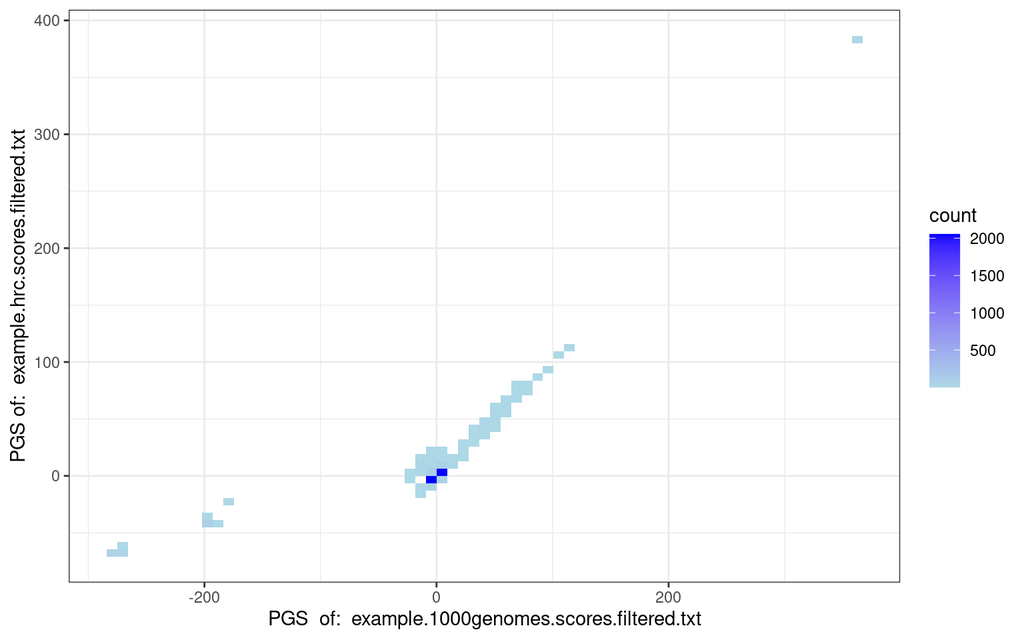

# Scatterplot and Density plot of z-values (normalized PGS-scores)

In order to compare the two files, it is necessary to normalize the Polygenic Scores ( = z-value), which is again plotted against each other.

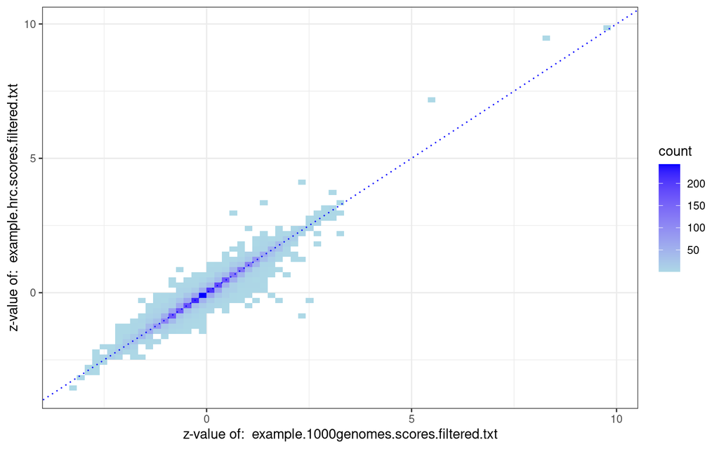

# Calculation of pearson correlation coefficient (r_pearson) grouped by PGS_number

The Pearson correlation coefficient is calculated within a PGS_number (e.g only within PGS000001, and not the global mean or global sample variance).

|  | sample | PGS_number | PGS_score1 | PGS_score2 | var1 | var2 | r_pearson |
| --- | --- | --- | --- | --- | --- | --- | --- |
| 1 | Sample_1 | PGS000003 | -0.567722798092291 | -0.558144866023213 | 0.146135095694039 | 0.147488487941299 | 0.998488179133768 |
| 2 | Sample_2 | PGS000003 | 0.263677074806765 | 0.244913257542066 | 0.146135095694039 | 0.147488487941299 | 0.998488179133768 |
| 3 | Sample_3 | PGS000003 | -0.470573429309297 | -0.467038945120294 | 0.146135095694039 | 0.147488487941299 | 0.998488179133768 |
| 4 | Sample_4 | PGS000003 | -0.583960184128955 | -0.551332057919353 | 0.146135095694039 | 0.147488487941299 | 0.998488179133768 |
| 5 | Sample_5 | PGS000003 | -0.343645531916991 | -0.339585068519227 | 0.146135095694039 | 0.147488487941299 | 0.998488179133768 |
| 6 | Sample_6 | PGS000003 | -0.333834392185963 | -0.315541254793061 | 0.146135095694039 | 0.147488487941299 | 0.998488179133768 |

|  | PGS_number | r_pearson |
| --- | --- | --- |
| 1 | PGS000003 | 0.998488179133768 |
| 2 | PGS000030 | 0.960635417353646 |
| 3 | PGS000102 | 0.9116846285441 |
| 4 | PGS000103 | 0.934731141223079 |
| 5 | PGS000109 | 0.942858995304571 |
| 6 | PGS000160 | 0.996092106549018 |
| 7 | PGS000177 | 0.913928767871901 |
| 8 | PGS000333 | 0.998203293041661 |
| 9 | PGS000363 | 0.999591508665716 |
| 10 | PGS000388 | 0.999474641246598 |

[output cut: 39 more lines]

### count of r_pearson exactely equal to 1

```
## [1] 0
```

# Histogram of r_pearson corresponding to the PGS_number

The histogram shows the value of the pearson correlation coefficient on the x-axis and the counts the number of times it occurs in the data.

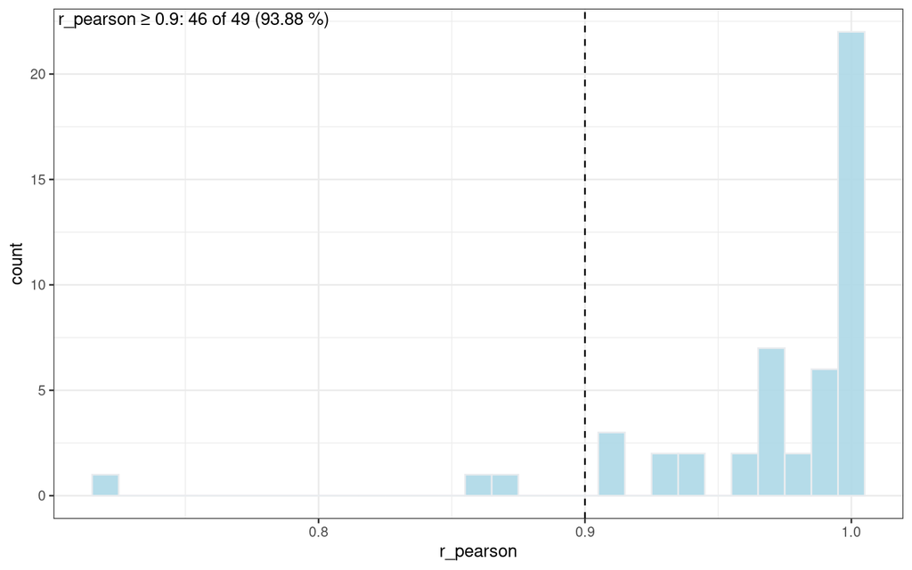

# Sorting of r_pearson (ascending order)

The pearson correlation coefficient as a measure of correlation between two variables. It ranges from 0 to 1, meaning no correlation (r = 0) and perfect correlation (r = 1). The lower values therefore represent the PGS’s where almost no correlation is to be seen.

|  | PGS_number | r_pearson |
| --- | --- | --- |
| 1 | PGS002416 | 0.724160302554177 |
| 2 | PGS002916 | 0.864328437970489 |
| 3 | PGS002392 | 0.869994086043318 |
| 4 | PGS002437 | 0.91126984086309 |
| 5 | PGS000102 | 0.9116846285441 |
| 6 | PGS000177 | 0.913928767871901 |
| 7 | PGS003215 | 0.927894054873696 |
| 8 | PGS000103 | 0.934731141223079 |
| 9 | PGS002827 | 0.938867494968078 |
| 10 | PGS000109 | 0.942858995304571 |

[output cut: 39 more lines]

# Comparison of coverage

In order to make sure that the correlation coefficient is not biased because of differences in the coverage of the samples, comparison is also made between the coverage of the two files (extra input files).

Input of corresponding coverage files to check for differences in PGS coverage.

Input Files:

- coverage of File A: *input/example.1000genomes.coverage.txt*
- coverage of File B: *input/example.hrc.coverage.txt*

|  | score | coverage_of_file01 | coverage_of_file02 |
| --- | --- | --- | --- |
| 1 | PGS000001 | 0.948051948051948 | 0.961038961038961 |
| 2 | PGS000002 | 0.948051948051948 | 0.961038961038961 |
| 3 | PGS000003 | 0.948051948051948 | 0.961038961038961 |
| 4 | PGS000004 | 1 | 0.769968051118211 |
| 5 | PGS000005 | 1 | 0.769968051118211 |
| 6 | PGS000006 | 1 | 0.769968051118211 |
| 7 | PGS000007 | 0.999738219895288 | 0.775130890052356 |
| 8 | PGS000008 | 0.999738219895288 | 0.775130890052356 |
| 9 | PGS000009 | 0.999738219895288 | 0.775130890052356 |
| 10 | PGS000010 | 0.777777777777778 | 0.777777777777778 |

[output cut: 3285 more lines]

|  | score | variants_total |
| --- | --- | --- |
| 1 | PGS000001 | 77 |
| 2 | PGS000002 | 77 |
| 3 | PGS000003 | 77 |
| 4 | PGS000004 | 313 |
| 5 | PGS000005 | 313 |
| 6 | PGS000006 | 313 |

|  | PGS_number | r_pearson | variants_total |
| --- | --- | --- | --- |
| 1 | PGS000003 | 0.998488179133768 | 77 |
| 2 | PGS000030 | 0.960635417353646 | 147 |
| 3 | PGS000102 | 0.9116846285441 | 28162 |
| 4 | PGS000103 | 0.934731141223079 | 22843 |
| 5 | PGS000109 | 0.942858995304571 | 26683 |
| 6 | PGS000160 | 0.996092106549018 | 79 |

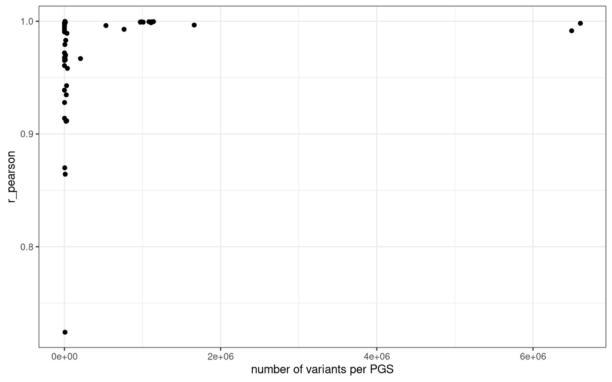

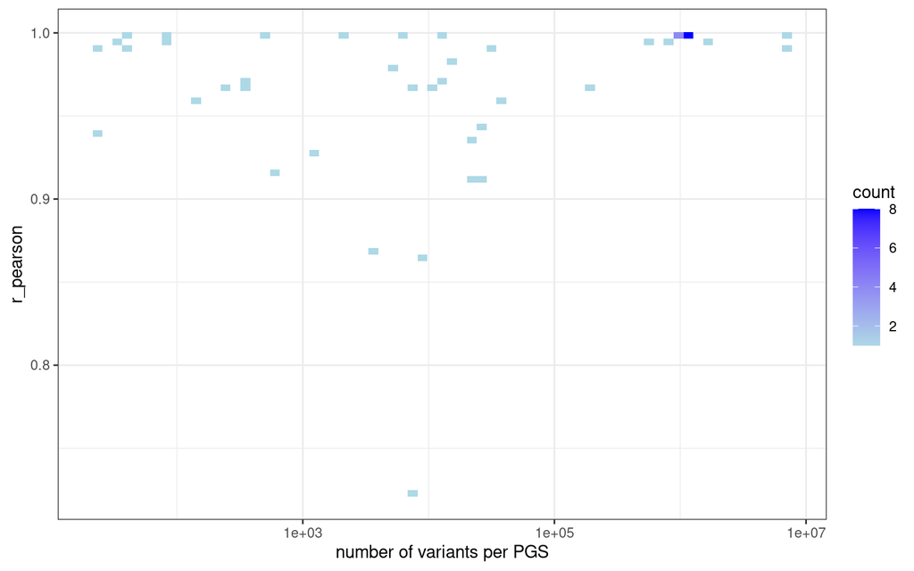

# Density and Barplot of coverage

Again a density and barplot is made.

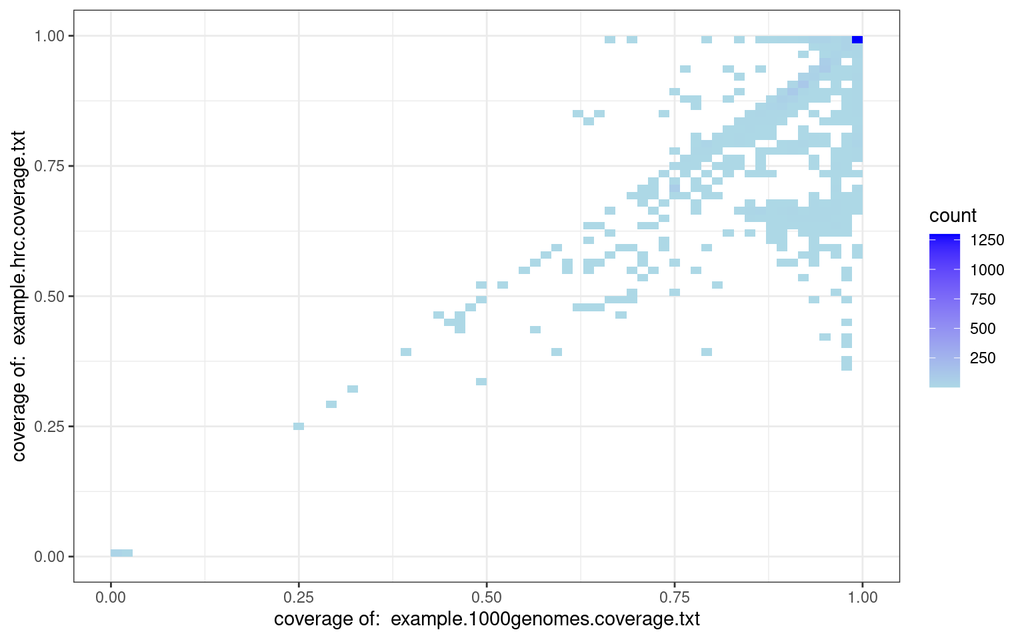

|  | score | file | coverage | bin |
| --- | --- | --- | --- | --- |
| 1 | PGS000001 | coverage_of_file01 | 0.948051948051948 | &gt; 0.9 |
| 2 | PGS000002 | coverage_of_file01 | 0.948051948051948 | &gt; 0.9 |
| 3 | PGS000003 | coverage_of_file01 | 0.948051948051948 | &gt; 0.9 |
| 4 | PGS000004 | coverage_of_file01 | 1 | &gt; 0.9 |
| 5 | PGS000005 | coverage_of_file01 | 1 | &gt; 0.9 |
| 6 | PGS000006 | coverage_of_file01 | 1 | &gt; 0.9 |
| 7 | PGS000007 | coverage_of_file01 | 0.999738219895288 | &gt; 0.9 |
| 8 | PGS000008 | coverage_of_file01 | 0.999738219895288 | &gt; 0.9 |
| 9 | PGS000009 | coverage_of_file01 | 0.999738219895288 | &gt; 0.9 |
| 10 | PGS000010 | coverage_of_file01 | 0.777777777777778 | 0.8 |

[output cut: 6580 more lines]

```
## # A tibble: 18 × 3
## # Groups:   file [2]
##    file               bin       n
##    <chr>              <fct> <int>
##  1 coverage_of_file01 ≤ 0.1    31
##  2 coverage_of_file01 0.3       2
##  3 coverage_of_file01 0.4       2
##  4 coverage_of_file01 0.5      12
##  5 coverage_of_file01 0.6      16
##  6 coverage_of_file01 0.7      41
##  7 coverage_of_file01 0.8     222
##  8 coverage_of_file01 0.9     403
##  9 coverage_of_file01 > 0.9  2566
## 10 coverage_of_file02 ≤ 0.1    31
## 11 coverage_of_file02 0.3       2
## 12 coverage_of_file02 0.4       9
## 13 coverage_of_file02 0.5      25
## 14 coverage_of_file02 0.6      56
## 15 coverage_of_file02 0.7     270
## 16 coverage_of_file02 0.8     326
## 17 coverage_of_file02 0.9     504
## 18 coverage_of_file02 > 0.9  2072
```

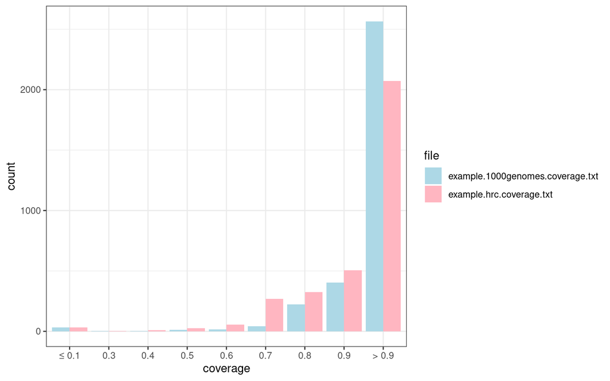